#### Setup: Python Imports

```python
import pandas as pd
import numpy as np
import matplotlib.mlab as mlab
import matplotlib.pyplot as plt
from pyspark.ml.classification import RandomForestClassifier
from pyspark.ml.evaluation import BinaryClassificationEvaluator
from pyspark.ml.feature import StringIndexer, VectorAssembler, OneHotEncoder
from pyspark.sql.functions import lit

%matplotlib inline
```

# Business Understanding

In the context of an (supposedly quick) interview exercise to demonstrate some critical skills as a Data Scientist, the goal of this exercise is not to create the best or the purest model, but rather to describe the steps we’ll take to accomplish it and explain the places that may have been the most challenging.

Let's find clear insights on the profiles of the people that make more than $50,000 / year. For example, which variables seem to be the most correlated with this phenomenon?

# Data Understanding

#### Data loading

- Import the learning and test files

```python
# the meta data
columnNames = [ w.replace(' ', '_') for w in [
    "age",
    "class of worker",
    "industry code",
    "occupation code",
    #"adjusted gross income",
    "education",
    "wage per hour",
    "enrolled in edu inst last wk",
    "marital status",
    "major industry code",
    "major occupation code",
    "race",
    "hispanic Origin",
    "sex",
    "member of a labor union",
    "reason for unemployment",
    "full or part time employment stat",
    "capital gains",
    "capital losses",
    "divdends from stocks",
    #"federal income tax liability",
    "tax filer status",
    "region of previous residence",
    "state of previous residence",
    "detailed household and family stat",
    "detailed household summary in household",
    "instance weight",
    "migration code-change in msa",
    "migration code-change in reg",
    "migration code-move within reg",
    "live in this house 1 year ago",
    "migration prev res in sunbelt",
    "num persons worked for employer",
    "family members under 18",
    #"total person earnings",
    "country of birth father",
    "country of birth mother",
    "country of birth self",
    "citizenship",
    "own business or self employed",
    "fill inc questionnaire for veteran's admin",
    "veterans benefits",
    "weeks worked in year",
    #"taxable income amount",
    "year",
    "total person income"
]]
targetColumn = "total_person_income"
lessThan50k = " - 50000."
print "Number of columns defined: " + str(len(columnNames))
train = pd.read_csv('us_census_full/census_income_learn.csv', header=None)
print "Number of columns in data frame: " + str(len(train.columns))
train.columns = columnNames
target = (train[targetColumn] != lessThan50k).astype(int)

train.head(1)
```

```
Number of columns defined: 42
Number of columns in data frame: 42
```

|  | age | class_of_worker | industry_code | occupation_code | education | wage_per_hour | enrolled_in_edu_inst_last_wk | marital_status | major_industry_code | major_occupation_code | ... | country_of_birth_father | country_of_birth_mother | country_of_birth_self | citizenship | own_business_or_self_employed | fill_inc_questionnaire_for_veteran's_admin | veterans_benefits | weeks_worked_in_year | year | total_person_income |
| --- | --- | --- | --- | --- | --- | --- | --- | --- | --- | --- | --- | --- | --- | --- | --- | --- | --- | --- | --- | --- | --- |
| 0 | 73 | Not in universe | 0 | 0 | High school graduate | 0 | Not in universe | Widowed | Not in universe or children | Not in universe | ... | United-States | United-States | United-States | Native- Born in the United States | 0 | Not in universe | 2 | 0 | 95 | - 50000. |

1 rows × 42 columns

#### Simple Data audit

- Make a quick statistic based and univariate audit of the different columns’ content and produce the results in visual / graphic format.
- This audit should describe the variable distribution, the % of missing values, the extreme values, and so on.

```python
def describe(df):
    # FIXME: add better legends
    for i in df.columns:
        print "***************************************"
        print "Describing Column " + str(i) + ":"
        numValues = pd.Series(df[i].values.ravel()).unique().size
        if df[i].dtype !=  np.object and numValues > 5:
            auditNumericalColumn(df, str(i))
        else:
            auditCategoricalColumn(df, str(i))

def auditNumericalColumn(df, columnName):
    col = df[columnName]
    print col.describe()
    fig = plt.figure()
    if col.dtype == np.int64:
        num_bins = pd.Series(col.values.ravel()).unique().size
    else:
        num_bins = 100
    data = [
        df[df[targetColumn] != lessThan50k][columnName].values,
        df[df[targetColumn] == lessThan50k][columnName].values
    ]
    f, axarr = plt.subplots(2, sharex=True)
    axarr[0].boxplot(data, vert = False, showmeans = True, whis = [2, 99])
    axarr[1].hist(data, num_bins, color = ['g','r'], stacked=True, alpha = 0.6)
    plt.title("Values Histogram of column:" + columnName)
    plt.xlabel("Values")
    plt.ylabel("count")
    plt.show()

def auditCategoricalColumn(df, columnName):
    col = df[columnName]
    total = col.count()
    counts = pd.DataFrame(col.value_counts(), columns=["count"])
    counts["%"] = counts["count"] * 100.0 / total
    print counts
    col.value_counts().plot(kind="bar")
    plt.show()
```

```
Describing Column age:
count    199523.000000
mean         34.494199
std          22.310895
min           0.000000
25%          15.000000
50%          33.000000
75%          50.000000
max          90.000000
Name: age, dtype: float64
```

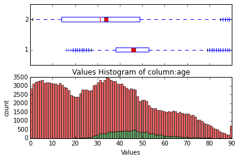

```
Describing Column class_of_worker:
                                  count          %
 Not in universe                 100245  50.242328
 Private                          72028  36.100099
 Self-employed-not incorporated    8445   4.232595
 Local government                  7784   3.901305
 State government                  4227   2.118553
 Self-employed-incorporated        3265   1.636403
 Federal government                2925   1.465996
 Never worked                       439   0.220025
 Without pay                        165   0.082697
```

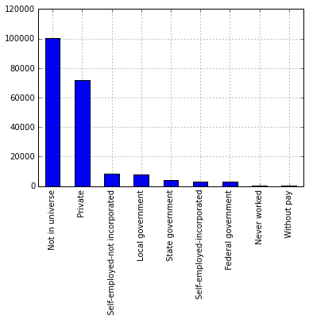

```
Describing Column industry_code:
count    199523.000000
mean         15.352320
std          18.067129
min           0.000000
25%           0.000000
50%           0.000000
75%          33.000000
max          51.000000
Name: industry_code, dtype: float64
```

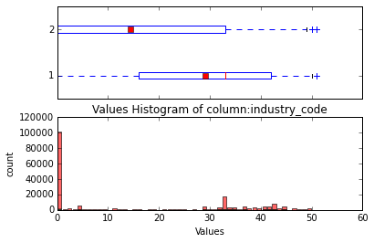

```
Describing Column occupation_code:
count    199523.000000
mean         11.306556
std          14.454204
min           0.000000
25%           0.000000
50%           0.000000
75%          26.000000
max          46.000000
Name: occupation_code, dtype: float64
```

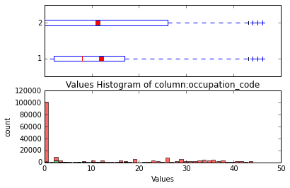

```
Describing Column education:
                                         count          %
 High school graduate                    48407  24.261363
 Children                                47422  23.767686
 Some college but no degree              27820  13.943255
 Bachelors degree(BA AB BS)              19865   9.956246
 7th and 8th grade                        8007   4.013071
 10th grade                               7557   3.787533
 11th grade                               6876   3.446219
 Masters degree(MA MS MEng MEd MSW MBA)   6541   3.278319
 9th grade                                6230   3.122447
 Associates degree-occup /vocational      5358   2.685405
 Associates degree-academic program       4363   2.186715
 5th or 6th grade                         3277   1.642417
 12th grade no diploma                    2126   1.065541
 1st 2nd 3rd or 4th grade                 1799   0.901650
 Prof school degree (MD DDS DVM LLB JD)   1793   0.898643
 Doctorate degree(PhD EdD)                1263   0.633010
 Less than 1st grade                       819   0.410479
```

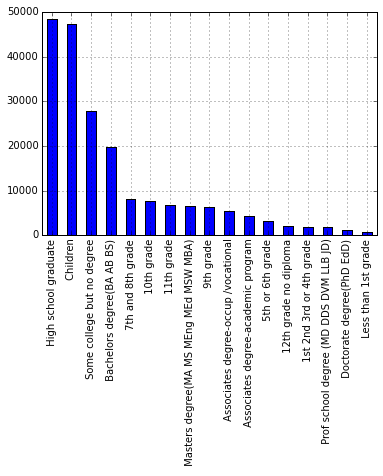

```
Describing Column wage_per_hour:
count    199523.000000
mean         55.426908
std         274.896454
min           0.000000
25%           0.000000
50%           0.000000
75%           0.000000
max        9999.000000
Name: wage_per_hour, dtype: float64
```

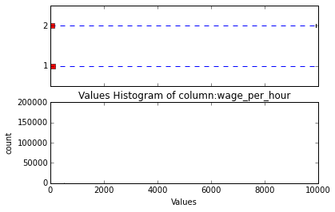

```
Describing Column enrolled_in_edu_inst_last_wk:
                         count          %
 Not in universe        186943  93.694962
 High school              6892   3.454238
 College or university    5688   2.850799
```

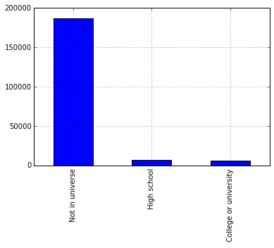

```
Describing Column marital_status:
                                  count          %
 Never married                    86485  43.345880
 Married-civilian spouse present  84222  42.211675
 Divorced                         12710   6.370193
 Widowed                          10463   5.244007
 Separated                         3460   1.734136
 Married-spouse absent             1518   0.760815
 Married-A F spouse present         665   0.333295
```

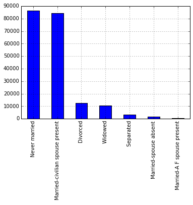

```
Describing Column major_industry_code:
                                       count          %
 Not in universe or children          100684  50.462353
 Retail trade                          17070   8.555405
 Manufacturing-durable goods            9015   4.518276
 Education                              8283   4.151401
 Manufacturing-nondurable goods         6897   3.456744
 Finance insurance and real estate      6145   3.079845
 Construction                           5984   2.999153
 Business and repair services           5651   2.832255
 Medical except hospital                4683   2.347098
 Public administration                  4610   2.310511
 Other professional services            4482   2.246358
 Transportation                         4209   2.109531
 Hospital services                      3964   1.986738
 Wholesale trade                        3596   1.802298
 Agriculture                            3023   1.515114
 Personal services except private HH    2937   1.472011
 Social services                        2549   1.277547
 Entertainment                          1651   0.827474
 Communications                         1181   0.591912
 Utilities and sanitary services        1178   0.590408
 Private household services              945   0.473630
 Mining                                  563   0.282173
 Forestry and fisheries                  187   0.093724
 Armed Forces                             36   0.018043
```

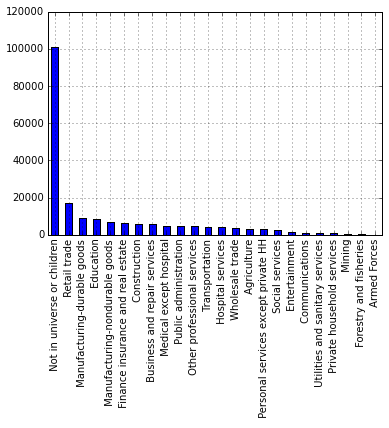

```
Describing Column major_occupation_code:
                                         count          %
 Not in universe                        100684  50.462353
 Adm support including clerical          14837   7.436235
 Professional specialty                  13940   6.986663
 Executive admin and managerial          12495   6.262436
 Other service                           12099   6.063963
 Sales                                   11783   5.905585
 Precision production craft & repair     10518   5.271573
 Machine operators assmblrs & inspctrs    6379   3.197125
 Handlers equip cleaners etc              4127   2.068433
 Transportation and material moving       4020   2.014805
 Farming forestry and fishing             3146   1.576761
 Technicians and related support          3018   1.512608
 Protective services                      1661   0.832485
 Private household services                780   0.390932
 Armed Forces                               36   0.018043
```

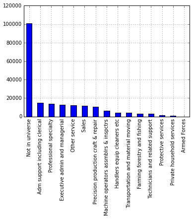

```
Describing Column race:
                               count          %
 White                        167365  83.882560
 Black                         20415  10.231903
 Asian or Pacific Islander      5835   2.924475
 Other                          3657   1.832871
 Amer Indian Aleut or Eskimo    2251   1.128191
```

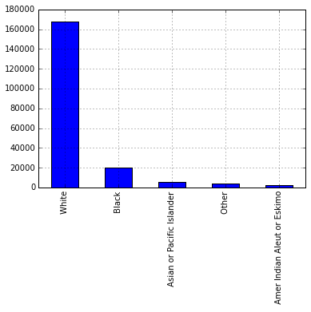

```
Describing Column hispanic_Origin:
                             count          %
 All other                  171907  86.158989
 Mexican-American             8079   4.049157
 Mexican (Mexicano)           7234   3.625647
 Central or South American    3895   1.952156
 Puerto Rican                 3313   1.660460
 Other Spanish                2485   1.245470
 Cuban                        1126   0.564346
 NA                            874   0.438045
 Do not know                   306   0.153366
 Chicano                       304   0.152363
```

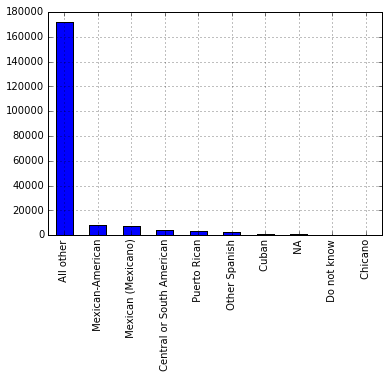

```
Describing Column sex:
          count          %
 Female  103984  52.116297
 Male     95539  47.883703
```

[30 more figures not shown]

```python
describe(train)
```

#### Audit the test data too

```python
test = pd.read_csv('us_census_full/census_income_test.csv', header=None, names=columnNames)
```

Let's check the [Population Stability Index](http://ucanalytics.com/blogs/population-stability-index-psi-banking-case-study/) (PSI) to see if the test data is in a similar context than the training data or if we need to ignore some features because they happened to be too different in the test dataset.

```python
epsilon = 0.005

def computePSI(actual, expected):
    a = epsilon
    act = actual.value_counts()
    totalAct = 1.0 * act.values.sum()
    exp = expected.value_counts();
    totalExp = 1.0 * exp.values.sum()
    for actKey in act.keys():
        if actKey not in exp.keys():
            exp = exp.append(pd.Series([a], index=[actKey]))
    for expKey in exp.keys():
        if expKey not in act.keys():
            act = act.append(pd.Series([a], index=[expKey]))
    act = act.values / totalAct
    exp = exp.values / totalExp
    try:
        PSI = (act - exp) * np.log(act / exp)
    except:
        print act, exp
    return PSI.sum()

for var_name in columnNames:
    if train[var_name].dtype != np.float64:
        PSI = computePSI(train[var_name], test[var_name])
        if PSI > epsilon:
            print var_name + " has a PSI of " + str(PSI)
```

```
wage_per_hour has a PSI of 0.00896227576458
divdends_from_stocks has a PSI of 0.00884941156761
```

All the PSI measures for each features seems to be quite low so we don't need to worry about it in this exercise but this could be used as a test on production data to detect any shift in the day-to-day data that are fed to the model once it is deployed.

This kind of verification would ensure that we would get alerted if there is a sudden change in the behavior of the population (which is not the context expected for this model to work properly)

#### Visualize without missing values

```python
missingValues = [
    " Not in universe",
    " ?"
]
def describeWithoutNull(df):
    for i in df.columns:
        numValues = pd.Series(df[i].values.ravel()).unique().size
        if df[i].dtype ==  np.object or numValues <= 5:
            print "***************************************"
            print "Describing Column " + str(i) + ":"
            auditCategoricalColumn(df[~df[i].isin(missingValues)], str(i))
```

```
Describing Column class_of_worker:
                                 count          %
 Private                         72028  72.551824
 Self-employed-not incorporated   8445   8.506416
 Local government                 7784   7.840609
 State government                 4227   4.257741
 Self-employed-incorporated       3265   3.288745
 Federal government               2925   2.946272
 Never worked                      439   0.442193
 Without pay                       165   0.166200
```

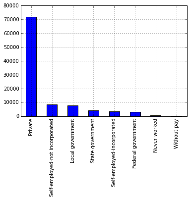

```
Describing Column education:
                                         count          %
 High school graduate                    48407  24.261363
 Children                                47422  23.767686
 Some college but no degree              27820  13.943255
 Bachelors degree(BA AB BS)              19865   9.956246
 7th and 8th grade                        8007   4.013071
 10th grade                               7557   3.787533
 11th grade                               6876   3.446219
 Masters degree(MA MS MEng MEd MSW MBA)   6541   3.278319
 9th grade                                6230   3.122447
 Associates degree-occup /vocational      5358   2.685405
 Associates degree-academic program       4363   2.186715
 5th or 6th grade                         3277   1.642417
 12th grade no diploma                    2126   1.065541
 1st 2nd 3rd or 4th grade                 1799   0.901650
 Prof school degree (MD DDS DVM LLB JD)   1793   0.898643
 Doctorate degree(PhD EdD)                1263   0.633010
 Less than 1st grade                       819   0.410479
```

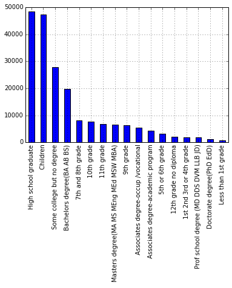

```
Describing Column enrolled_in_edu_inst_last_wk:
                        count          %
 High school             6892  54.785374
 College or university   5688  45.214626
```

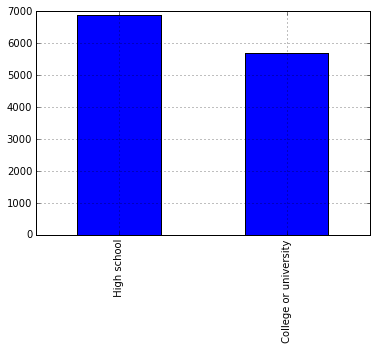

```
Describing Column marital_status:
                                  count          %
 Never married                    86485  43.345880
 Married-civilian spouse present  84222  42.211675
 Divorced                         12710   6.370193
 Widowed                          10463   5.244007
 Separated                         3460   1.734136
 Married-spouse absent             1518   0.760815
 Married-A F spouse present         665   0.333295
```

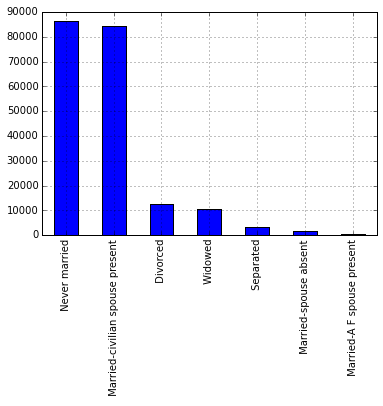

```
Describing Column major_industry_code:
                                       count          %
 Not in universe or children          100684  50.462353
 Retail trade                          17070   8.555405
 Manufacturing-durable goods            9015   4.518276
 Education                              8283   4.151401
 Manufacturing-nondurable goods         6897   3.456744
 Finance insurance and real estate      6145   3.079845
 Construction                           5984   2.999153
 Business and repair services           5651   2.832255
 Medical except hospital                4683   2.347098
 Public administration                  4610   2.310511
 Other professional services            4482   2.246358
 Transportation                         4209   2.109531
 Hospital services                      3964   1.986738
 Wholesale trade                        3596   1.802298
 Agriculture                            3023   1.515114
 Personal services except private HH    2937   1.472011
 Social services                        2549   1.277547
 Entertainment                          1651   0.827474
 Communications                         1181   0.591912
 Utilities and sanitary services        1178   0.590408
 Private household services              945   0.473630
 Mining                                  563   0.282173
 Forestry and fisheries                  187   0.093724
 Armed Forces                             36   0.018043
```

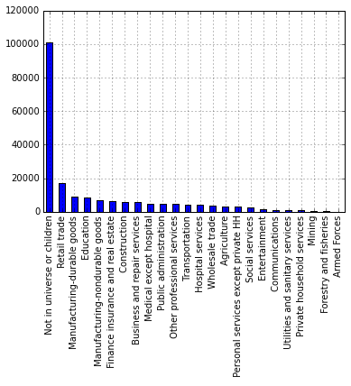

```
Describing Column major_occupation_code:
                                        count          %
 Adm support including clerical         14837  15.011281
 Professional specialty                 13940  14.103744
 Executive admin and managerial         12495  12.641771
 Other service                          12099  12.241119
 Sales                                  11783  11.921408
 Precision production craft & repair    10518  10.641548
 Machine operators assmblrs & inspctrs   6379   6.453930
 Handlers equip cleaners etc             4127   4.175477
 Transportation and material moving      4020   4.067220
 Farming forestry and fishing            3146   3.182954
 Technicians and related support         3018   3.053451
 Protective services                     1661   1.680511
 Private household services               780   0.789162
 Armed Forces                              36   0.036423
```

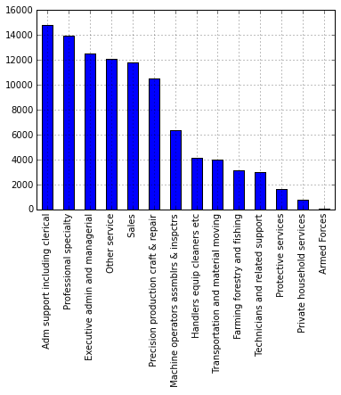

```
Describing Column race:
                               count          %
 White                        167365  83.882560
 Black                         20415  10.231903
 Asian or Pacific Islander      5835   2.924475
 Other                          3657   1.832871
 Amer Indian Aleut or Eskimo    2251   1.128191
```

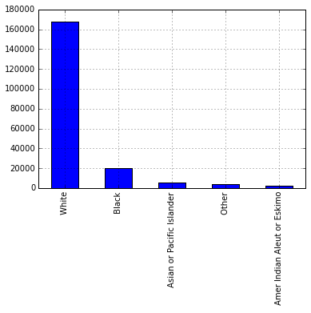

```
Describing Column hispanic_Origin:
                             count          %
 All other                  171907  86.158989
 Mexican-American             8079   4.049157
 Mexican (Mexicano)           7234   3.625647
 Central or South American    3895   1.952156
 Puerto Rican                 3313   1.660460
 Other Spanish                2485   1.245470
 Cuban                        1126   0.564346
 NA                            874   0.438045
 Do not know                   306   0.153366
 Chicano                       304   0.152363
```

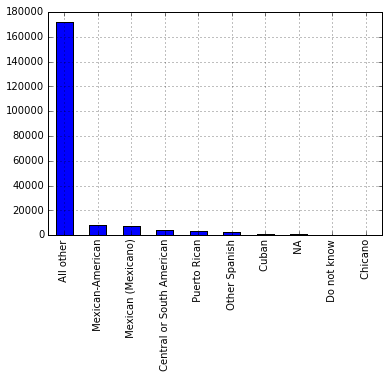

```
Describing Column sex:
          count          %
 Female  103984  52.116297
 Male     95539  47.883703
```

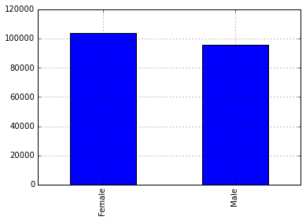

```
Describing Column member_of_a_labor_union:
      count          %
 No   16034  84.106169
 Yes   3030  15.893831
```

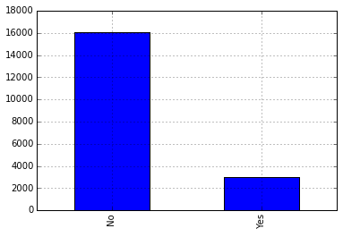

```
Describing Column reason_for_unemployment:
                        count          %
 Other job loser         2038  33.574959
 Re-entrant              2019  33.261944
 Job loser - on layoff    976  16.079077
 Job leaver               598   9.851730
 New entrant              439   7.232290
```

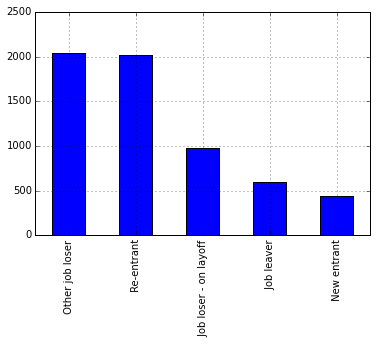

```
Describing Column full_or_part_time_employment_stat:
                                      count          %
 Children or Armed Forces            123769  62.032447
 Full-time schedules                  40736  20.416694
 Not in labor force                   26808  13.436045
 PT for non-econ reasons usually FT    3322   1.664971
 Unemployed full-time                  2311   1.158262
 PT for econ reasons usually PT        1209   0.605945
 Unemployed part- time                  843   0.422508
 PT for econ reasons usually FT         525   0.263128
```

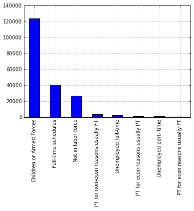

```
Describing Column tax_filer_status:
                               count          %
 Nonfiler                      75094  37.636764
 Joint both under 65           67383  33.772046
 Single                        37421  18.755231
 Joint both 65+                 8332   4.175960
 Head of household              7426   3.721877
 Joint one under 65 & one 65+   3867   1.938122
```

[20 more figures not shown]

```python
describeWithoutNull(train)
```

#### Study missing values

Rows with missing values shouldn't be ignored completely but a deeper analysis of why it is happening and looking for any obvious pattern could be critical to better understand the data (or the way the data was acquired).

```python
# FIXME
```

# Data Preparation

#### Convert to Spark DataFrame

```python
trainDF = sqlContext.createDataFrame(train)
testDF = sqlContext.createDataFrame(test)
```

#### Encode categorical features

```python
# assemble multiple columns into a single vector column
def prepareData(df):
    vectorAssembler = VectorAssembler(inputCols = [ w.replace(' ', '_') for w in [
        "age",
        "class of worker",
        "industry code",
        "occupation code",
        #"adjusted gross income",
        "education",
        "wage per hour",
        "enrolled in edu inst last wk",
        "marital status",
        "major industry code",
        "major occupation code",
        "race",
        "hispanic Origin",
        "sex",
        "member of a labor union",
        "reason for unemployment",
        "full or part time employment stat",
        "capital gains",
        "capital losses",
        "divdends from stocks",
        #"federal income tax liability",
        "tax filer status",
        "region of previous residence",
        "state of previous residence",
        "detailed household and family stat",
        "detailed household summary in household",
        #"instance weight",
        "migration code-change in msa",
        "migration code-change in reg",
        "migration code-move within reg",
        "live in this house 1 year ago",
        "migration prev res in sunbelt",
        "num persons worked for employer",
        "family members under 18",
        #"total person earnings",
        "country of birth father",
        "country of birth mother",
        "country of birth self",
        "citizenship",
        "own business or self employed",
        "fill inc questionnaire for veteran's admin",
        "veterans benefits",
        "weeks worked in year",
        #"taxable income amount",
        "year"
    ]], outputCol = "features")
    return vectorAssembler.transform(df)

# for each string feature, build a string indexer model
def modelEncoders(df):
    models = {}
    selectedFeatures = []
    for i in df.columns:
        if df.select(i).dtypes[0][1] == 'string':
            stringIndexer = StringIndexer(inputCol = i,
                                          outputCol = "str_" + i)
            models[i] = stringIndexer.fit(df)
    return models

# for each string feature, transform it into double index using the string models
def encodeStringFeatures(df, models):
    selectedFeatures = []
    for i in df.columns:
        if df.select(i).dtypes[0][1] == 'string':
            model = models[i]
            indexed = model.transform(df)
            if i == targetColumn:
                df = indexed.drop(i).withColumnRenamed("str_" + i, i)
            else:
                encoder = OneHotEncoder(dropLast=False, inputCol="str_" + i, outputCol=i)
                encoded = encoder.transform(indexed.drop(i))
                df = encoded
            selectedFeatures.append(i)
        else:
            selectedFeatures.append(i)
    return df.select(selectedFeatures)

stringModels = modelEncoders(trainDF)
trainData = prepareData(encodeStringFeatures(trainDF, stringModels))
testData = prepareData(encodeStringFeatures(testDF, stringModels))
print trainData.select(targetColumn, "features").head()
```

```
Row(total_person_income=0.0, features=SparseVector(408, {0: 73.0, 1: 1.0, 12: 1.0, 30: 1.0, 36: 1.0, 40: 1.0, 64: 1.0, 79: 1.0, 84: 1.0, 94: 1.0, 96: 1.0, 99: 1.0, 107: 1.0, 116: 1.0, 122: 1.0, 128: 1.0, 185: 1.0, 221: 1.0, 225: 1.0, 235: 1.0, 244: 1.0, 254: 1.0, 257: 1.0, 262: 1.0, 267: 1.0, 310: 1…
```

I am using OneHotEncoder which creates a new boolean column for each category value but I should investigate in the future the use of VectorIndexer instead as it seems to be more adequate to our use case and might improve performances: [see documentation here](https://spark.apache.org/docs/latest/ml-features.html#vectorindexer) for handling categorical features

However, since it would be a waste (in terms of lean development) to work on this aspect for now, I am leaving it out (ie result could still be achieved without it)

# Modeling

- Create a model using these variables (you can use whichever variables you want, or even create you own; for example, you could find the ratio or relationship between different variables, the binarisation of “categorical” variables, etc.) to modelize earning more or less than $50,000 / year. Here, the idea would be for you to test one or two algorithms, type regression logistics, or a decision tree. But, you are free to choose others if you’d rather.

#### Random Forest model

```python
def trainRandomForest(df):
    rf = RandomForestClassifier(labelCol=targetColumn,
                                featuresCol="features",
                                rawPredictionCol="rawPrediction",
                                probabilityCol="probability",
                                numTrees=50)
    model = rf.fit(df)
    return model
```

- Choose the model that appears to have the highest performance based on a comparison between reality (the 42nd variable) and the model’s prediction.

From [MLLib documentation](https://spark.apache.org/docs/latest/mllib-evaluation-metrics.html):

## Classification model evaluation

While there are many different types of classification algorithms, the evaluation of classification models all share similar principles. In a supervised classification problem, there exists a true output and a model-generated predicted output for each data point. For this reason, the results for each data point can be assigned to one of four categories:

- True Positive (TP) - label is positive and prediction is also positive
- True Negative (TN) - label is negative and prediction is also negative
- False Positive (FP) - label is negative but prediction is positive
- False Negative (FN) - label is positive but prediction is negative

These four numbers are the building blocks for most classifier evaluation metrics. A fundamental point when considering classifier evaluation is that pure accuracy (i.e. was the prediction correct or incorrect) is not generally a good metric. The reason for this is because a dataset may be highly unbalanced. For example, if a model is designed to predict fraud from a dataset where 95% of the data points are not fraud and 5% of the data points are fraud, then a naive classifier that predicts not fraud, regardless of input, will be 95% accurate. For this reason, metrics like precision and recall are typically used because they take into account the type of error. In most applications there is some desired balance between precision and recall, which can be captured by combining the two into a single metric, called the F-measure.

Here is a list of some possible measurements (from Dataiku's DSS):

- Accuracy Score: Proportion of correct predictions (positive and negative) in the sample
- Average Precision Score: Average precision for all classes
- F1 Score: Harmonic mean of Precision and Recall
- Hamming Loss: The Hamming loss is the fraction of labels that are incorrectly predicted. (The lower the better)
- Log Loss: Error metric that takes into account the predicted probabilities
- Matthews Correlation Coefficient: The MCC is a correlation coefficient between actual and predicted classifications; +1 is perfect, -1 means no correlation
- Precision Score: Proportion of correct 'positive' predictions in the sample
- ROC - AUC Score: From 0.5 (random model) to 1 (perfect model).
- Recall Score

```python
def measurePerformance(data, model = None):
    print
    print "Perfect Model"
    data.crosstab(targetColumn, targetColumn).show()

    print "Random Forest"
    if model == None:
        model = trainRandomForest(data)
    predictions = model.transform(data)
    confusionMat = predictions.crosstab(targetColumn, "prediction")
    if "1.0" in confusionMat.columns:
        confusionMat.show()
    else:
        confusionMat.withColumn("1.0", lit(0)).show()

    evaluator = BinaryClassificationEvaluator(rawPredictionCol="rawPrediction", labelCol=targetColumn)
    print "Area Under ROC Curve: " + str(evaluator.evaluate(predictions))
    print "Area Under Precision-Recall Curve: " + str(evaluator.evaluate(predictions, {evaluator.metricName: "areaUnderPR"}))

    print "Precision:", evaluatePrecision(confusionMat)
    return model

def evaluatePrecision(confusionMat):
    tp, fp, tn, fn = getConfusionMatrixCells(confusionMat)
    if (tp + fp) != 0:
        return tp * 1.0 / (tp + fp)
    else:
        return 0.0

def getConfusionMatrixCells(confusionMat):
    if "1.0" in confusionMat.columns:
        #True Positive (TP) - label is positive and prediction is also positive
        tp = confusionMat.where(confusionMat[targetColumn + "_prediction"] == "1.0").collect()[0]['1.0']
        #False Positive (FP) - label is negative but prediction is positive
        fp = confusionMat.where(confusionMat[targetColumn + "_prediction"] == "0.0").collect()[0]['1.0']
    else:
        tp = 0.0
        fp = 0.0
    if "0.0" in confusionMat.columns:
        #True Negative (TN) - label is negative and prediction is also negative
        tn = confusionMat.where(confusionMat[targetColumn + "_prediction"] == "0.0").collect()[0]['0.0']
        #False Negative (FN) - label is positive but prediction is negative
        fn = confusionMat.where(confusionMat[targetColumn + "_prediction"] == "1.0").collect()[0]['0.0']
    else:
        tn = 0.0
        fn = 0.0
    return tp, fp, tn, fn
```

```python
print "Always returning 0"
trainData.withColumn("always0", lit(0)).crosstab(targetColumn, "always0").withColumn("1.0", lit(0)).show()

#print "Always returning 1"
#trainData.withColumn("always1", lit(1)).crosstab(targetColumn, "always1").withColumn("0.0", lit(0)).show()

firstModel = measurePerformance(trainData)
```

```
Always returning 0
+---------------------------+------+---+
|total_person_income_always0|     0|1.0|
+---------------------------+------+---+
|                        1.0| 12382|  0|
|                        0.0|187141|  0|
+---------------------------+------+---+


Perfect Model
+---------------------------------------+-----+------+
|total_person_income_total_person_income|  1.0|   0.0|
+---------------------------------------+-----+------+
|                                    1.0|12382|     0|
|                                    0.0|    0|187141|
+---------------------------------------+-----+------+

Random Forest
+------------------------------+------+---+
|total_person_income_prediction|   0.0|1.0|
+------------------------------+------+---+
|                           1.0| 12382|  0|
|                           0.0|187141|  0|
+------------------------------+------+---+

Area Under ROC Curve: 0.925782096884
Area Under Precision-Recall Curve: 0.526448597715
Precision: 0.0
```

Obviously, we see that something terribly wrong is happening as our very complicated piece of machine learning, Random Forest, is making exactly the same predictions as returning the same label (0.0) all the time. This is caused by the very unbalanced dataset as we have seen on previous charts...

However, I wanted to make sure that i would be able to produce some models as fast as possible, regardless of the accuracy results at first. Now there is a full pipeline in place, we should be able to start the creative work and iterate as fast as possible while trying different methods and compare results with previous runs and slowly improve our predictions in a more efficient manner.

So, let's now follow the "standard" Data Mining process (CRISP-DM) and go back to improve our predictions:

[figure not shown]

# Data Preparation

#### Stratified Sampling: Down sample

Since the dataset is very unbalanced, the easiest (and fastest solution to implement) to this issue is to throw away data by "down sampling" the rows with the majority class (warning: this might not be the best solution!)

```python
def downSample(df, factor = 1.0):
    targetCount = (df
       .groupBy(targetColumn).count()
       .sort("count", ascending= True)
       .map(lambda x: (x[targetColumn], x["count"]))
       .collect())
    fractions = {
        targetCount[0][0] : 1.0,
        targetCount[1][0] : (targetCount[0][1] * 1.0 / targetCount[1][1]) * factor
    }
    return df.sampleBy(targetColumn, fractions)

sampleTrainData = downSample(trainData)
sampleTrainData.groupBy(targetColumn).count().show()
```

```
+-------------------+-----+
|total_person_income|count|
+-------------------+-----+
|                1.0|12382|
|                0.0|12436|
+-------------------+-----+
```

# Modeling

```python
secondModel = measurePerformance(sampleTrainData)
```

```
Perfect Model
+---------------------------------------+-----+-----+
|total_person_income_total_person_income|  1.0|  0.0|
+---------------------------------------+-----+-----+
|                                    1.0|12382|    0|
|                                    0.0|    0|12436|
+---------------------------------------+-----+-----+

Random Forest
+------------------------------+-----+----+
|total_person_income_prediction|  1.0| 0.0|
+------------------------------+-----+----+
|                           1.0|11437| 945|
|                           0.0| 3168|9268|
+------------------------------+-----+----+

Area Under ROC Curve: 0.918393627481
Area Under Precision-Recall Curve: 0.908132474914
Precision: 0.783087983567
```

The Random Forest model is now properly making more predictions instead of classifying everything in the same category all the time...

#### Cross-Validation

To avoid overfitting and have a more objective view of our model performances, we can implement a cross-validation where we split our training data into multiple training and evaluation partitions.

```python
# FIXME
```

## Evaluation

- Apply your model to the test file and measure its real performance on it (same method as above).

```python
measurePerformance(testData, firstModel)
measurePerformance(testData, secondModel)
```

```
Perfect Model
+---------------------------------------+----+-----+
|total_person_income_total_person_income| 1.0|  0.0|
+---------------------------------------+----+-----+
|                                    1.0|6186|    0|
|                                    0.0|   0|93576|
+---------------------------------------+----+-----+

Random Forest
+------------------------------+-----+---+
|total_person_income_prediction|  0.0|1.0|
+------------------------------+-----+---+
|                           1.0| 6186|  0|
|                           0.0|93576|  0|
+------------------------------+-----+---+

Area Under ROC Curve: 0.925770507246
Area Under Precision-Recall Curve: 0.523264748566
Precision: 0.0

Perfect Model
+---------------------------------------+----+-----+
|total_person_income_total_person_income| 1.0|  0.0|
+---------------------------------------+----+-----+
|                                    1.0|6186|    0|
|                                    0.0|   0|93576|
+---------------------------------------+----+-----+

Random Forest
+------------------------------+-----+-----+
|total_person_income_prediction|  1.0|  0.0|
+------------------------------+-----+-----+
|                           1.0| 5697|  489|
|                           0.0|24402|69174|
+------------------------------+-----+-----+

Area Under ROC Curve: 0.915858869302
Area Under Precision-Recall Curve: 0.482029109184
Precision: 0.189275391209
```

```
RandomForestClassificationModel (uid=rfc_b5c7fc0672f4) with 50 trees
```

Fine-tune the evaluation function to reflect some imaginary business cost of misclassifications instead...

This is only an example to show that we should adapt this evaluation to the business use case. It is also an effective way to communicate the results back to non-technical audience.

```python
def measureBusinessPerformance(data, model = None):
    if model == None:
        model = trainRandomForest(data)
    predictions = model.transform(data)
    confusionMat = predictions.crosstab(targetColumn, "prediction")
    if "1.0" in confusionMat.columns:
        confusionMat.show()
    else:
        confusionMat.withColumn("1.0", lit(0)).show()

    tp, fp, tn, fn = getConfusionMatrixCells(confusionMat)
    print "We offered a $50 gift to", int(tp), "customers that might be interested in a luxury saving account, avg ROI is $100"
    print "We offered a $50 gift to", int(fp), "customers that were not interested and declined the offer"
    print int(tn + fn), "customers were not contacted and they never purchased our banking services"
    print "Total marketing investment was: $" + str((tp + fp) * 50)
    print "ROI: $" + str( (tp * 100) +
                         (fp * -50) +
                         (tn *   0) +
                         (fn *   0) )
    return model

measureBusinessPerformance(testData, firstModel)
measureBusinessPerformance(testData, secondModel)
```

```
+------------------------------+-----+---+
|total_person_income_prediction|  0.0|1.0|
+------------------------------+-----+---+
|                           1.0| 6186|  0|
|                           0.0|93576|  0|
+------------------------------+-----+---+

We offered a $50 gift to 0 customers that might be interested in a luxury saving account, avg ROI is $100
We offered a $50 gift to 0 customers that were not interested and declined the offer
99762 customers were not contacted and they never purchased our banking services
Total marketing investment was: $0.0
ROI: $0.0
+------------------------------+-----+-----+
|total_person_income_prediction|  1.0|  0.0|
+------------------------------+-----+-----+
|                           1.0| 5697|  489|
|                           0.0|24402|69174|
+------------------------------+-----+-----+

We offered a $50 gift to 5697 customers that might be interested in a luxury saving account, avg ROI is $100
We offered a $50 gift to 24402 customers that were not interested and declined the offer
69663 customers were not contacted and they never purchased our banking services
Total marketing investment was: $1504950
ROI: $-650400
```

```
RandomForestClassificationModel (uid=rfc_b5c7fc0672f4) with 50 trees
```

If we were to roll out that model, we would lose money!

Let's try to learn more about people not having more than $50000 so we make less costly mistakes...

We can do this by rebalancing the dataset but give more importance to the label 0.0 by providing 3 times more data. (note that we shouldn't use the testData to figure what the right parameters are but use the cross validation of train data instead)

```python
sample2TrainData = downSample(trainData, 3.0)
sample2TrainData.groupBy(targetColumn).count().show()
thirdModel = measurePerformance(sample2TrainData)
measurePerformance(testData, thirdModel)
```

```
+-------------------+-----+
|total_person_income|count|
+-------------------+-----+
|                1.0|12382|
|                0.0|36961|
+-------------------+-----+


Perfect Model
+---------------------------------------+-----+-----+
|total_person_income_total_person_income|  1.0|  0.0|
+---------------------------------------+-----+-----+
|                                    1.0|12382|    0|
|                                    0.0|    0|36961|
+---------------------------------------+-----+-----+

Random Forest
+------------------------------+----+-----+
|total_person_income_prediction| 1.0|  0.0|
+------------------------------+----+-----+
|                           1.0|6447| 5935|
|                           0.0|1347|35614|
+------------------------------+----+-----+

Area Under ROC Curve: 0.920770152543
Area Under Precision-Recall Curve: 0.799243224272
Precision: 0.827174749808

Perfect Model
+---------------------------------------+----+-----+
|total_person_income_total_person_income| 1.0|  0.0|
+---------------------------------------+----+-----+
|                                    1.0|6186|    0|
|                                    0.0|   0|93576|
+---------------------------------------+----+-----+

Random Forest
+------------------------------+----+-----+
|total_person_income_prediction| 1.0|  0.0|
+------------------------------+----+-----+
|                           1.0|3205| 2981|
|                           0.0|3382|90194|
+------------------------------+----+-----+

Area Under ROC Curve: 0.920773741494
Area Under Precision-Recall Curve: 0.515857856037
Precision: 0.486564445119
```

```
RandomForestClassificationModel (uid=rfc_3e4fd267883c) with 50 trees
```

```python
measureBusinessPerformance(testData, thirdModel)
```

```
+------------------------------+----+-----+
|total_person_income_prediction| 1.0|  0.0|
+------------------------------+----+-----+
|                           1.0|3205| 2981|
|                           0.0|3382|90194|
+------------------------------+----+-----+

We offered a $50 gift to 3205 customers that might be interested in a luxury saving account, avg ROI is $100
We offered a $50 gift to 3382 customers that were not interested and declined the offer
93175 customers were not contacted and they never purchased our banking services
Total marketing investment was: $329350
ROI: $151400
```

```
RandomForestClassificationModel (uid=rfc_3e4fd267883c) with 50 trees
```

Of course, this is far from being the best model (I even picked some parameters randomly) but with more time to work on this exercise, we can iterate on and on through the CRISP-DM process to bring the evaluation function up to a satisfactory point where we can decide to deploy it into some "production" environment.

My point here is that I wanted to show a base pipeline that is quickly built in few hours of work (in this context of interview exercise) rather than a "perfect" solution handling all the data aspects in order to get the best score out of this. This is best described in this article: http://www.techrepublic.com/article/start-tackling-data-science-inefficiencies-by-properly-defining-waste/

However here are some ideas of aspects to work on to improve even more the predictions:

#### Resampling: Up sampling (SMOTE?)

Instead of throwing away data, we can synthetize or duplicate the rows from minority class instead to rebalance the dataset.

```python
# FIXME
```

#### Rescaling

Not necessary for Random Forest but might be useful for other modeling algorithms

```python
from sklearn.preprocessing import scale

# FIXME
```

#### Binning

Combine variables into bins based on [Weight Of Evidence](http://www.listendata.com/2015/03/weight-of-evidence-woe-and-information.html) while increasing [Information Value](http://ucanalytics.com/blogs/information-value-and-weight-of-evidencebanking-case/)

#### Grouping Categorical Nominal characteristic:

1. For each Categorical Nominal variable, we start with one value per bin. So if we have N possible values, we have N bins.
2. We compute the Information Value.
3. Then we try every combinations of two bins and simulate a merge to recompute the new Information Value if they were grouped together.
4. We pick the pair of bins that provides the biggest change to Information Value between step 2 and 3 and we apply the merge
5. We reiterate with step 2 until we can't find any pairs that increase the Information Value anymore.

#### Grouping Binary characteristic:

Binary characteristics contains by definition only 2 potential values, therefore, no further grouping is possible.

#### Grouping Categorical Ordinal and Numerical Continuous characteristics:

1. We start by transforming each value into an interval tuple with a lower and upper bound
2. For each Categorical Ordinal variable, we start with one value per bin. So if we have N possible values, we have N bins.
3. We compute the Information Value.
4. Then we try every combinations of two adjacent bins (the bin at index i and index i + 1) and simulate a merge to recompute the new Information Value if they were grouped together so that we produce a range of values. Grouping two bins results into taking the lower bound of the first bin and the upper bound of the second bin to produce the merged bin.
5. We pick the pair of bins that provides the biggest change to Information Value between step 2 and 3 and we apply the merge
6. We reiterate with step 2 until we can't find any pairs that increase the Information Value anymore.

Note that with ordinal value, we make sure to merge only adjacent values. we are simply growing the intervals when possible without skipping values.

```python
# FIXME
```

#### Parameter Optimization - fine tuning

```python
# FIXME
```

#### Feature engineering

*Coming up with features is difficult, time-consuming, requires expert knowledge. "Applied machine learning" is basically feature engineering.*

— Andrew Ng

```python
# FIXME
```